## Richard Safran Student ID: 998862635

# Assignment 5

In this assignment, you'll scrape text from [The California Aggie](https://theaggie.org/) and then analyze the text.

The Aggie is organized by category into article lists. For example, there's a [Campus News](https://theaggie.org/campus/) list, [Arts & Culture](https://theaggie.org/arts/) list, and [Sports](https://theaggie.org/sports/) list. Notice that each list has multiple pages, with a maximum of 15 articles per page.

The goal of exercises 1.1 - 1.3 is to scrape articles from the Aggie for analysis in exercise 1.4.

```python
#Question 1.1 and Question 1.2
import requests
import requests_ftp
import requests_cache
import urllib2
from bs4 import BeautifulSoup

#Question 1.3
import pandas as pd

#Question 1.4
import nltk, re, pprint
from nltk import corpus
from nltk.tokenize import RegexpTokenizer
from nltk.stem.porter import PorterStemmer
from collections import Counter
from sklearn.feature_extraction.text import TfidfVectorizer
from sklearn.neighbors import NearestNeighbors
from sklearn.neighbors import KNeighborsRegressor
from sklearn.metrics.pairwise import linear_kernel
from nltk.corpus import stopwords
from scipy.sparse import csr_matrix
from itertools import izip

#Plotting
import numpy as np
from matplotlib import pyplot as plt
%matplotlib inline
from __future__ import division
plt.style.use('ggplot')
import wordcloud
from wordcloud import WordCloud, STOPWORDS
import random

#Cacheing
requests_cache.install_cache('aggie_assign_5')
```

**Exercise 1.1.** Write a function that extracts all of the links to articles in an Aggie article list. The function should:

- Have a parameter `url` for the URL of the article list.
- Have a parameter `page` for the number of pages to fetch links from. The default should be `1`.
- Return a list of aricle URLs (each URL should be a string).

Test your function on 2-3 different categories to make sure it works.

Hints:

- Be polite to The Aggie and save time by setting up [requests_cache](https://pypi.python.org/pypi/requests-cache) before you write your function.
- Start by getting your function to work for just 1 page. Once that works, have your function call itself to get additional pages.
- You can use [lxml.html](http://lxml.de/lxmlhtml.html) or [BeautifulSoup](https://www.crummy.com/software/BeautifulSoup/bs4/doc/) to scrape HTML. Choose one and use it throughout the entire assignment.

```python
def links_per_page(url):
    """
    Input string url link.
    Returns a one item list of links to articles.
    """
    aggie_req = requests.get(url) #Ping the server
    aggie_html = aggie_req.text #Obtain the text file of the webstie
    aggie = BeautifulSoup(aggie_html, 'lxml') #Change to html code
    urls = [x.findNext().get('href') for x in aggie.findAll('h2')] #Use h2 to look for the article url. All articles across all pages are located in the h2 tab. Extracting this seciton will provide an easy approach to extracting the website urls.
    return urls
```

```python
def allLinks(pathway, num_page = 1):
    """
    Function arguements:
    string = complete url pathway
    int = number of pages of articles requested
    returns a list of urls for articles where each list item contains all urls on that page.
    """
    pages_requested = range(1, num_page + 1)
    link = [(pathway + 'page/' + str(x) + '/') for x in pages_requested]
    links = [links_per_page(x) for x in link]
    return(links)
allLinks("http://theaggie.org/sports/",2)
```

```
[['https://theaggie.org/2017/02/21/what-are-your-thoughts-on-uc-davis-athletics/',
  'https://theaggie.org/2017/02/20/a-day-in-the-life-of-an-athletic-trainer/',
  'https://theaggie.org/2017/02/19/a-lifetime-of-tennis/',
  'https://theaggie.org/2017/02/17/uc-davis-womens-basketball-team-holds-off-uc-irvine-62-42/',
  'https://theaggie.org/2017/02/17/nba-awards-at-the-all-star-break/',
  'https://theaggie.org/2017/02/17/womens-lacrosse-soars-over-the-blackbirds/',
  'https://theaggie.org/2017/02/17/uc-davis-womens-lacrosse-falls-in-tough-season-opener/',
  'https://theaggie.org/2017/02/16/uc-davis-softball-falls-in-home-opener/',
  'https://theaggie.org/2017/02/16/ags-compensate-for-recent-loss-to-highlanders-with-decisive-win/',
  'https://theaggie.org/2017/02/13/uc-davis-athletes-excel-academically/',
  'https://theaggie.org/2017/02/12/a-beginners-guide-to-womens-gymnastics/',
  'https://theaggie.org/2017/02/10/inside-the-game-chima-moneke/',
  'https://theaggie.org/2017/02/10/uc-davis-victorious-in-clash-with-titans/',
  'https://theaggie.org/2017/02/09/uc-davis-women-dominate-in-back-to-back-matchups/',
  'https://theaggie.org/2017/02/09/uc-davis-womens-swimming-and-diving-team-finishes-season-strong-with-home-win-over-pacific/'],
 ['https://theaggie.org/2017/02/09/super-bowl-li-recap/',
  'https://theaggie.org/2017/02/06/inside-the-game-roy-boateng/',
  'https://theaggie.org/2017/02/02/the-patriots-are-going-to-win-super-bowl-li/',
  'https://theaggie.org/2017/02/02/uc-davis-mens-basketball-dominates-usurps-uc-irvine/',
  'https://theaggie.org/2017/01/31/hotlanta-heats-up-houston/',
  'https://theaggie.org/2017/01/31/womens-water-polo-struggles-in-first-matches-of-season/',
  'https://theaggie.org/2017/01/29/rodgers-falls-short-in-attempt-to-run-the-table/',
  'https://theaggie.org/2017/01/28/uc-davis-womens-basketball-team-rides-monstrous-third-quarter-to-victory-over-uc/',
  'https://theaggie.org/2017/01/26/womens-basketball-prepares-to-take-on-uc-riverside/',
  'https://theaggie.org/2017/01/26/womens-tennis-is-a-doubles-force-to-be-reckoned-with-this-season/',
  'https://theaggie.org/2017/01/26/mens-basketball-looks-to-stay-hot-against-uc-irvine/',
  'https://theaggie.org/2017/01/23/isaiah-thomas-is-on-fire-right-now/',
  'https://theaggie.org/2017/01/22/wwpa-coach-of-the-year-daniel-leyson/',
  'https://theaggie.org/2017/01/20/now-on-to-the-nfl-conference-championships/',
  'https://theaggie.org/2017/01/20/womens-gymnastics-soar-in-three-events-at-opener/']]
```

**Exercise 1.2.** Write a function that extracts the title, text, and author of an Aggie article. The function should:

- Have a parameter `url` for the URL of the article.
- For the author, extract the "Written By" line that appears at the end of most articles. You don't have to extract the author's name from this line.
- Return a dictionary with keys "url", "title", "text", and "author". The values for these should be the article url, title, text, and author, respectively.

For example, for [this article](https://theaggie.org/2017/02/14/project-toto-aims-to-address-questions-regarding-city-finances/) your function should return something similar to this:

```
{
    'author': u'Written By: Bianca Antunez \xa0\u2014\xa0city@theaggie.org',
    'text': u'Davis residents create financial model to make city\'s financial state more transparent To increase transparency between the city\'s financial situation and the community, three residents created a model called Project Toto which aims to improve how the city communicates its finances in an easily accessible design. Jeff Miller and Matt Williams, who are members of Davis\' Finance and Budget Commission, joined together with Davis entrepreneur Bob Fung to create the model plan to bring the project to the Finance and Budget Commission in February, according to Kelly Stachowicz, assistant city manager. "City staff appreciate the efforts that have gone into this, and the interest in trying to look at the city\'s potential financial position over the long term," Stachowicz said in an email interview. "We all have a shared goal to plan for a sound fiscal future with few surprises. We believe the Project Toto effort will mesh well with our other efforts as we build the budget for the next fiscal year and beyond." Project Toto complements the city\'s effort to amplify the transparency of city decisions to community members. The aim is to increase the understanding about the city\'s financial situation and make the information more accessible and easier to understand. The project is mostly a tool for public education, but can also make predictions about potential decisions regarding the city\'s financial future. Once completed, the program will allow residents to manipulate variables to see their eventual consequences, such as tax increases or extensions and proposed developments "This really isn\'t a budget, it is a forecast to see the intervention of these decisions," Williams said in an interview with The Davis Enterprise. "What happens if we extend the sales tax? What does it do given the other numbers that are in?" Project Toto enables users, whether it be a curious Davis resident, a concerned community member or a city leader, with the ability to project city finances with differing variables. The online program consists of the 400-page city budget for the 2016-2017 fiscal year, the previous budget, staff reports and consultant analyses. All of the documents are cited and accessible to the public within Project Toto. "It\'s a model that very easily lends itself to visual representation," Mayor Robb Davis said. "You can see the impacts of decisions the council makes on the fiscal health of the city." Complementary to this program, there is also a more advanced version of the model with more in-depth analyses of the city\'s finances. However, for an easy-to-understand, simplistic overview, Project Toto should be enough to help residents comprehend Davis finances. There is still more to do on the project, but its creators are hard at work trying to finalize it before the 2017-2018 fiscal year budget. "It\'s something I have been very much supportive of," Davis said. "Transparency is not just something that I have been supportive of but something we have stated as a city council objective [ ] this fits very well with our attempt to inform the public of our challenges with our fiscal situation." ',
    'title': 'Project Toto aims to address questions regarding city finances',
    'url': 'https://theaggie.org/2017/02/14/project-toto-aims-to-address-questions-regarding-city-finances/'
}
```

Hints:

- The author line is always the last line of the last paragraph.
- Python 2 displays some Unicode characters as `\uXXXX`. For instance, `\u201c` is a left-facing quotation mark. You can convert most of these to ASCII characters with the method call (on a string)

  ```
  .translate({ 0x2018:0x27, 0x2019:0x27, 0x201C:0x22, 0x201D:0x22, 0x2026:0x20 })
  ```

  If you're curious about these characters, you can look them up on [this page](http://unicode.org/cldr/utility/character.jsp), or read more about [what Unicode is](http://unicode.org/standard/WhatIsUnicode.html).

```python
def article_elements(article):
    """
    Input: String of complete url
    Output: Dictionary containing author, text, title, and url of article
    """
    aggie_req_art = requests.get(article) #Ping the server
    aggie_html_art = aggie_req_art.text #Obtain the text file of the webstie
    aggie_art = BeautifulSoup(aggie_html_art, 'lxml') #Change to html code

    adict = {'author':'','text':'','title':'','url':''} #Initialize the dictionary

    #Grab the title by looking for the class entry-title. Text in entry-title is the title of the article.
    adict['title'] = aggie_art.find_all('h1',attrs={'class':'entry-title'})[0].get_text().encode('ascii', 'ignore')

    #The url is the one given in the function. Therefore, can append to the dictionary
    adict['url'] = article.encode('ascii', 'ignore')

    #Isolate the main body of the article.
    body_text = aggie_art.find_all('div',attrs={'itemprop':'articleBody'})[0] #Itemprop named articleBody contains all of the writing found in the article excluding the title.
    paragraph = body_text.find_all('p') # Obtain a list of all of the paragraphs in the article. Contains text.

    #Obtain the text in the article
    #If FLICKR image is attached it grabs the subheading. Therefore, if statement checks to see if flickr is found in the text of the first paragraph. If so it takes out the portion before FLICKR, starting the article at the appropriate section.
    if (paragraph[0].getText().find("FLICKR") != -1) == True:
        main_text_start = paragraph[0].getText().split("FLICKR")[1] + " "
    else:
        main_text_start = paragraph[0].getText() + " "
    main_text = main_text_start + " ".join([x.getText() for x in paragraph[1:-1]]) #Last item in list is author so take everything but the last element and join in a string.
    adict['text'] = main_text.encode('ascii', 'ignore') #Change unicode numeric values to actual values.

    #Obtain the author of the article
    author_section = paragraph[len(paragraph)-1].getText() #Author is the last item in the main body list
    try:
        author_search = re.search("Written [Bb]y: [A-z]{1,20} [A-z]{2,20}", author_section)
        author_section = author_search.group(0)
        author = re.split("Written [Bb]y: ", author_section, flags=re.IGNORECASE)[-1] #Author has different html forms so finding written by will always grab the author.
        adict['author'] = author.encode('ascii', 'ignore')
    except:
        adict['author'] = "NA"
    return adict

article_elements("https://theaggie.org/2017/02/14/project-toto-aims-to-address-questions-regarding-city-finances/")
```

```
{'author': 'Bianca Antunez',
 'text': 'Davis residents create financial model to make citys financial state more transparent To increase transparency between the citys financial situation and the community, three residents created a model called Project Toto which aims to improve how the city communicates its finances in an eas…
 'title': 'Project Toto aims to address questions regarding city finances',
 'url': 'https://theaggie.org/2017/02/14/project-toto-aims-to-address-questions-regarding-city-finances/'}
```

**Exercise 1.3.** Use your functions from exercises 1.1 and 1.2 to get a data frame of 60 [Campus News](https://theaggie.org/campus/) articles and a data frame of 60 [City News](https://theaggie.org/city/) articles. Add a column to each that indicates the category, then combine them into one big data frame.

The "text" column of this data frame will be your corpus for natural language processing in exercise 1.4.

```python
#Create the data frame for the campus section
campus_links = allLinks("https://theaggie.org/campus/", 4)
campus_articles = [indvidiaul for page in campus_links for indvidiaul in page]
articles_campus_df = pd.DataFrame([article_elements(article) for article in campus_articles])
articles_campus_df['Category']='Campus'

#Create the dataframe for the city section
city_links = allLinks("https://theaggie.org/city/", 4)
city_articles = [indvidiaul for page in city_links for indvidiaul in page]
articles_city_df = pd.DataFrame([article_elements(article) for article in city_articles])
articles_city_df['Category']='City'

articles_df = pd.concat([articles_campus_df,articles_city_df], ignore_index=True)
articles_df.head()
```

|  | author | text | title | url | Category |
| --- | --- | --- | --- | --- | --- |
| 0 | Alyssa Vandenberg | Shaheens name to remain on ballot, his votes w... | Senate candidate Zaki Shaheen withdraws from race | https://theaggie.org/2017/02/22/senate-candida... | Campus |
| 1 | Aaron Liss | Students receive email warnings from UC Davis ... | UC Davis experiences several recent hate-based... | https://theaggie.org/2017/02/21/uc-davis-exper... | Campus |
| 2 | Alyssa Vandenberg | UC Board of Regents to vote on the appointment... | UC President selects Gary May as new UC Davis ... | https://theaggie.org/2017/02/21/uc-president-s... | Campus |
| 3 | Jeanna Totah | Tighter policies require greater approval of o... | Katehi controversy prompts decline of UC admin... | https://theaggie.org/2017/02/20/katehi-controv... | Campus |
| 4 | Ivan Valenzuela | SR #7 asks university to increase capacity for... | ASUCD Senate passes resolution submitting comm... | https://theaggie.org/2017/02/20/asucd-senate-p... | Campus |

**Exercise 1.4.** Use the Aggie corpus to answer the following questions. Use plots to support your analysis.

- What topics does the Aggie cover the most? Do city articles typically cover different topics than campus articles?
- What are the titles of the top 3 pairs of most similar articles? Examine each pair of articles. What words do they have in common?
- Do you think this corpus is representative of the Aggie? Why or why not? What kinds of inference can this corpus support? Explain your reasoning.

Hints:

- The [nltk book](http://www.nltk.org/book/) and [scikit-learn documentation](http://scikit-learn.org/stable/modules/feature_extraction.html#text-feature-extraction) may be helpful here.
- You can determine whether city articles are "near" campus articles from the similarity matrix or with k-nearest neighbors.
- If you want, you can use the [wordcloud](http://amueller.github.io/word_cloud/) package to plot a word cloud. To install the package, run

  ```
  conda install -c https://conda.anaconda.org/amueller wordcloud
  ```

  in a terminal. Word clouds look nice and are easy to read, but are less precise than bar plots.

#### What topics does the Aggie cover the most? Do city articles typically cover different topics than campus articles? Answered using wordclouds and bar plots

```python
#Lecture Functions
stemmer = PorterStemmer().stem
tokenize = nltk.word_tokenize

def stem(tokens,stemmer = PorterStemmer().stem):
    return [stemmer(w.lower()) for w in tokens]

def lemmatize(text):
    """
    Extract simple lemmas based on tokenization and stemming
    Input: string
    Output: list of strings (lemmata)
    """
    return stem(tokenize(text))
```

```
Words in all article titles scaled to prevalency
```

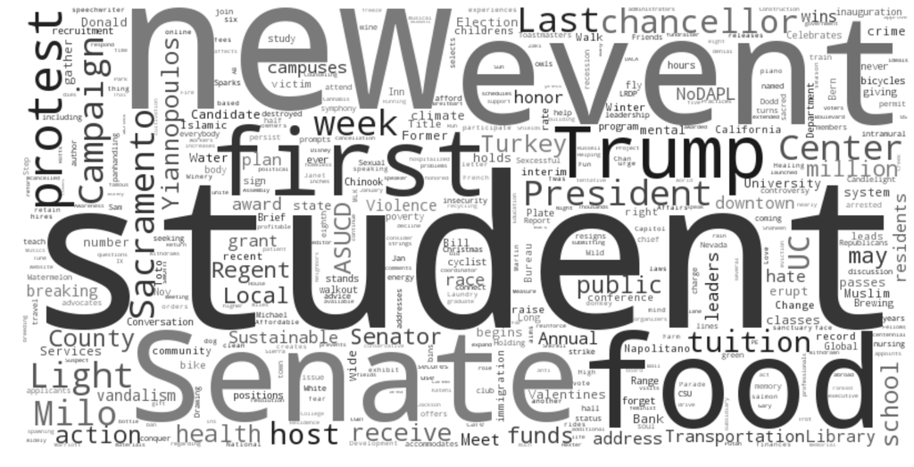

```python
# Stopwords: Words not included in similarity index
my_stopwords = set(["said","really","going","also","come","don't","will","UC","Davis","year","campus","city","police","logs","Yolo","day"])
stopwords = set(STOPWORDS).union(my_stopwords)

#Wordcloud of all of the titles captured.
this_text = list((" ".join(articles_df["title"])).split(" "))
interested = " ".join([item for item in this_text if item not in stopwords])

print "Words in all article titles scaled to prevalency"
image = WordCloud(background_color = "white", max_words=800, stopwords=stopwords, width=800, height=400) #Create the background
image.generate(interested) #Superimpose the image above the background

def grey_color_func(word, font_size, position, orientation, random_state=None, **kwargs):
    """
    Changes the coloring, size, font, position, and orientaiton of the word based on counter.
    """
    return "hsl(50, 0%%, %d%%)" % random.randint(10, 50)

# Create the actual plot
plt.figure(figsize=(25,10))
plt.imshow(image.recolor(color_func = grey_color_func, random_state=3))
plt.axis("off")
plt.tight_layout(pad=0)
plt.show()
```

```
Campus
```

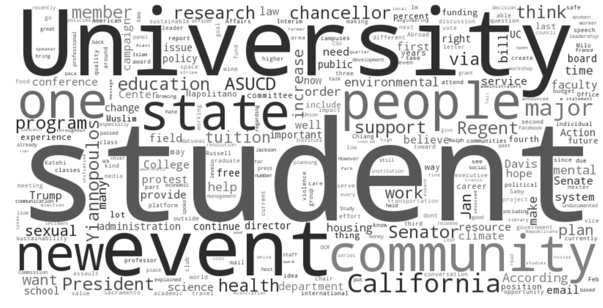

```
City
```

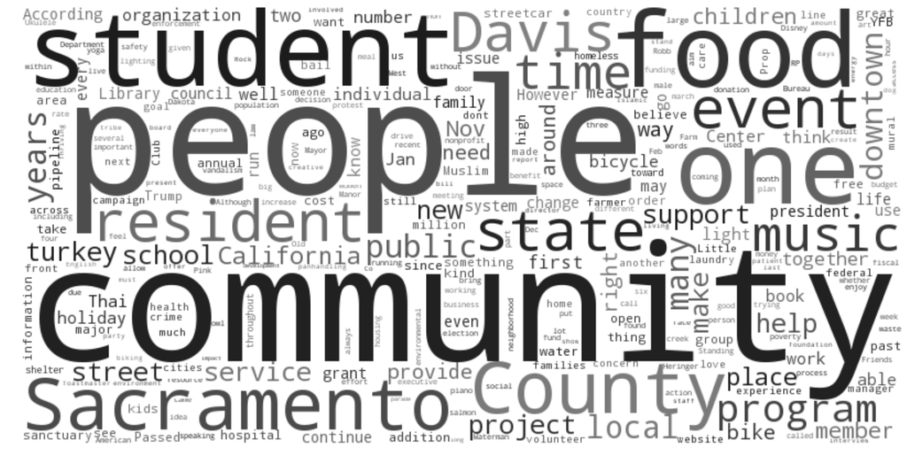

```python
#Wordclouds for campus and city individually.
place = ["Campus", "City"]
for category in place:
    this_text = list((" ".join(articles_df["text"][articles_df["Category"] == category])).split(" "))
    interested = " ".join([item for item in this_text if item not in stopwords])
    print category
    image = WordCloud(background_color = "white", max_words=300, stopwords=stopwords, width=800, height=400) #Create the background
    image.generate(interested) #Superimpose the image above the background

    # Create the actual plot
    plt.figure(figsize=(20,10))
    plt.imshow(image.recolor(color_func = grey_color_func, random_state=3))
    plt.axis("off")
    plt.tight_layout(pad=0)
    plt.show()
```

The first wordcloud contains both the city and the campus with the stop words removed. The second wodcloud covers just campus articles and the third wordclouds covers just city articles. The student wordcloud contains words that predominantly relate to campus events, such as students, events, community, ASUCD, as well as major news happening in the US, with Presidential elections, and controversial speaker Milo Yiannopolous. This makes sense as the campus section is expected to cover material pertaining directly to UC Davis. The city section covers a wider range of material predominantly centered on communial events and places in the area such as community, food, people, Davis, and downtown. Therefore, while there is a significant amount of crossover between campus and community articles, there is a distinct difference in focus that is representative of the categorization. Overall, based on these two categoires the Aggie covers predominant events happening in the surrounding community, national news, and lifestyle events.

```python
def Word_Counter(col_name, stops_to_add = {}):
    """
    Input: text in string or unicode from, set of words to be excluded from the counting process.
    Output: Counter class with number of occurences of each word in the string.
    """
    tokenizer = RegexpTokenizer(r'\w+')

    #Expand stopwords to only include words of interest. I only included filler words that would not add anything to my analysis.
    stopwords = set(STOPWORDS).union(stops_to_add)

    #Obtain a list of "important" words
    real_words = [word for word in tokenizer.tokenize(col_name) if word not in stopwords]

    #Find the lemmas corresponding to the words of interest.
    lemmatize_real_words = [lemmatize(x) for x in real_words]
    lemmata = [item for sublist in lemmatize_real_words for item in sublist]

    return Counter(lemmata)
```

```python
#Acquire the top 20 most reoccruing words when additional stopwords are added
gr_stops =  Counter()
for article_text in articles_df["text"]:
    gr_stops = gr_stops + Word_Counter(article_text, set(["said","really","going","also","come","don't","will","UC","Davis","year","campus","city","police","logs","Yolo","day"]))
top_words_stops = gr_stops.most_common(20)

#Acquire the top 20 most reoccuring words when no additonal stopwords are added
gr = Counter()
for article_text in articles_df["text"]:
    gr = gr + Word_Counter(article_text)
top_words = gr.most_common(20)
```

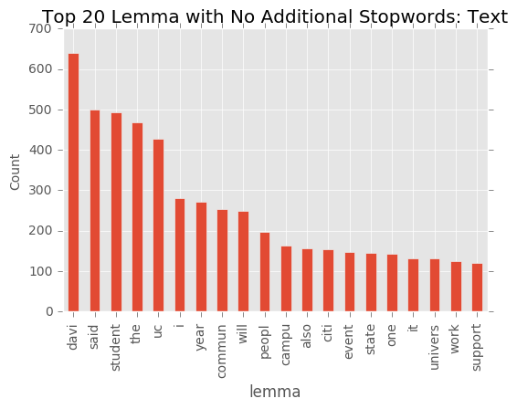

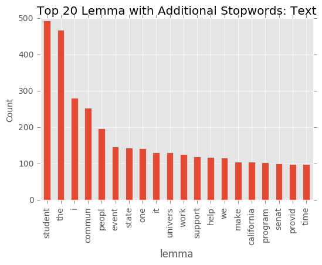

```python
#Set up the dataframe for no additional stopwords
df = pd.DataFrame(top_words, columns = ["lemma","count"])
df = df.set_index("lemma")

#Set up the dataframe for additional stopwords
df_stops = pd.DataFrame(top_words_stops, columns = ["lemma","count"])
df_stops = df_stops.set_index("lemma")

#Create the 2 plots
ax = df.plot.bar(grid=True,legend=False)
ax.set_ylabel("Count", fontsize=10)
ax.set_title("Top 20 Lemma with No Additional Stopwords: Text")
ax = df_stops.plot.bar(grid=True, legend=False)
ax.set_ylabel("Count", fontsize=10)
ax.set_title("Top 20 Lemma with Additional Stopwords: Text")
plt.show()
```

The bar graphs above examine the counts of the top 20 most prevelant lemmas with the first graph only using the predetermined stopwords and the second graph using my additional stopwords. While it appears that some of my lemma are stop words, like "the" and "i", these are words that have been reduced down through lemmatization and therefore do not get captured by the stopwords. Examining the graphs it becomes apparent that there are specifc words that occur significantly more frequently than others. In the base stopword graph there are 5 count above 400 and no other values above 300. These five lemmas are "davi", "said", "student", "the", and "uc". It makes sense that Davi is high due to the Aggie covering UC Davis. The same llogic is true of UC and student. Said and the are externalities since these do not provide much useful information about the topic being covered. Examining past these 5 words there are similar topics related to community and students, reinforcing the wordclouds acquired above.

Examining the graph with the additional stopwords there is a bigger discrepancy between the top words and the rest of around 200-300 count. The stopwords added included words such as UC, Davis, said, and words that related more to geographic location or article type, like police log. Using this type of filtering I found that a large amount of the articles related to student activities, events, community news, university news, and state news. This makes sense since the Aggie as a Campus run newsaper would tend to cover more local events than national events as the readerbase would turn to larger news outlet for national news.

#### What are the titles of the top 3 pairs of most similar articles? Examine each pair of articles. What words do they have in common?

```python
def sort_coo(m):
    """
    Input: tuple
    Output: tuple sorted.
    """
    tuples = izip(m.row, m.col, m.data)
    return sorted(tuples, key=lambda x: (x[0], x[2]), reverse = True)
```

```python
#Use vectorization to figure out which three articles are most closely related.
vectorizer = TfidfVectorizer(tokenizer=lemmatize,stop_words="english",smooth_idf=True,norm=None)
tfs = vectorizer.fit_transform(articles_df["text"])
sim = tfs.dot(tfs.T) #Perform the dot matrix to get a 120 x 120 size matrix.
sim_matrix = csr_matrix(sim) #Use sparse matrix to acquire a score for each article pair
sim_matrix_df = pd.DataFrame(sim_matrix.toarray()) #Turn the article pairs into a dataframe
print sim_matrix_df.head()
```

```
           0            1            2             3             4    \
0  3544.681551   628.164750   565.002076    672.924380   1243.898416
1   628.164750  8240.733081  1102.885035   1792.740030   1899.439277
2   565.002076  1102.885035  3062.553631   2041.406636   1519.008996
3   672.924380  1792.740030  2041.406636  10923.414794   2732.128089
4  1243.898416  1899.439277  1519.008996   2732.128089  12318.351915

           5            6            7            8            9    \
0   804.377790  1082.611715  1026.876998   568.596034  1585.484382
1  1860.887481  2272.520227  2452.806768  1062.874438  2924.055755
2  1808.526045  1951.295898  2088.307933   853.505935  2075.266618
3  3019.748472  2821.637030  2664.356287  1529.304687  3404.492903
4  3232.814676  3138.820625  3327.723974  1878.172763  4087.620979

      ...               110          111          112         113  \
```

[output cut: 21 more lines]

```python
#Figure out which three articles are the most closely related.
y = sim_matrix.tocoo()
ordered_sim = sort_coo(y) #Order the articles based on the articles first and the size second. Top value of each article now found every 120 values (number of columns in a row)
same_art = ordered_sim[0::120] #Since the articles are ordered in the way described above the top similiarty score for each article will occur every 120th value. Therefore extract these.
#Since there were articles along the diagonal that were not compared to itself, this means that an article was more similar to another article than itself. This is a potential concern that is addressed at the end of the seciton.

#Since don't care about articles compared to themselves find the articles that recieved the highest similiarty score excluding the same article.
most_sim = []
for x in range(len(same_art)):
    if (same_art[x][0] != same_art[x][1]) == True: #Make sure that the original article does not match the comparison article
        most_sim.append(same_art[x])

top_three_sim = sorted(most_sim, key=lambda x: x[2], reverse = True)[0:3] #Find the top 3 values after acquring the sorted list with no comparisons to itself.

# 3 Pairs most closely related articles
print "The top 3 most related article pairs are: "
print "Group 1: "+articles_df["title"][top_three_sim[0][0]],"+",articles_df["title"][top_three_sim[0][1]]
print "Group 2: "+articles_df["title"][top_three_sim[1][0]],"+",articles_df["title"][top_three_sim[1][1]]
print "Group 3: "+articles_df["title"][top_three_sim[2][0]],"+",articles_df["title"][top_three_sim[2][1]]
```

```
The top 3 most related article pairs are:
Group 1: 2017 ASUCD Winter Elections  Meet the Candidates + Drawing the lines of community ideals
Group 2: Construction of the All Student Center at Davis High begins + 2017 ASUCD Winter Elections  Meet the Candidates
Group 3: Russell Boulevard intramural fields withdrawn from 2017-2027 Long Range Development Plan + Student regent recruitment for the 2018-2019 school year begins
```

While the article pairings seem like they could be similar there are some major concerns with this model. These concerns are due to the nature of determining similairty in a sparse matrix. In a sparse matrix the scores are determined by the amount of words that match across the two articles being compared. The problem arises when the similiarity score inflates due to one article being small compared to the other. In this situation the small article can use words that are repeated many times in the larger article, resulting in the larger article recieving a high similiarty score to the smaller article due to sheer length. This occurs to such an extent that in multiple cases an article was matched more closely to another article than itself. Consequently, I would recommend using a weighted measure in the future as having drastic legnths in article can result in dramatic skews and false interpretations of the data.

Despite the findings listed in the prior paragraph the article pairings seem to be relevant or cover similar material. For instance, in group 1 it would make sense that ASUCD elections would cover the community ideals since the senators and president would seek to match the ideals with their platform. For group 2 the same ASUCD elcetions should cover pressing topics like construction occuring on campus. For group 3, the events occruing on Russell Bouevard could have a direct impact on recruitment or could be twisted to promote UC Davis to incoming students.

```python
def Word_present(col_name, stops_to_add = {}):
    """
    Input: text in string or unicode from, set of words to be excluded from the counting process.
    Output: Counter class with number of occurences of each word in the string.
    """
    tokenizer = RegexpTokenizer(r'\w+')

    #Expand stopwords to only include words of interest. I only included filler words that would not add anything to my analysis.
    stopwords = set(STOPWORDS).union(stops_to_add)

    #Obtain a list of "important" words
    real_words = [word for word in tokenizer.tokenize(col_name) if word not in stopwords]

    return real_words
```

```python
def common_elements(list1, list2):
    """
    Input: 2 lists
    Output: list of all similar values
    """
    return [element for element in list1 if element in list2]

def shared(first, second, stops_to_add = {}):
    """
    Input: two strings
    Output: All shared unique words
    """
    words_pair_1= Word_present(first, stops_to_add) #Acquire only the important words and don't care about counts
    unique_words_1 = np.unique(words_pair_1) #Want only the unique words so get rid of duplicates
    words_pair_2 = Word_present(second, stops_to_add) #Acquire only the important words and don't care about counts
    unique_words_2 = np.unique(words_pair_2) #Want only the unique words so get rid of duplicates
    return common_elements(unique_words_1,unique_words_2) #Join the two lists based on only common elements
```

```python
#Obtain the list of shared words in each of the 3 most similar articles.
list_shared = [shared(articles_df["text"][top_three_sim[item][0]],articles_df["text"][top_three_sim[item][1]],set(["said","really","going","also","come","don't","will","UC","Davis","year","campus","city","police","logs","Yolo","day","UCs","A","I","In","It","The","This","We","As","He"])) for item in range(3)]
df_shared = pd.DataFrame(list_shared).T
df_shared.columns = ["Group 1", "Group 2", "Group 3"]
df_shared.head(30)
```

|  | Group 1 | Group 2 | Group 3 |
| --- | --- | --- | --- |
| 0 | City | Center | 2016 |
| 1 | Council | Student | 2017 |
| 2 | addition | Students | City |
| 3 | already | addition | Mayor |
| 4 | always | body | Planning |
| 5 | amount | budget | Regents |
| 6 | areas | collaborative | Student |
| 7 | artists | coming | They |
| 8 | based | community | University |
| 9 | big | didnt | body |
| 10 | budget | double | campuses |
| 11 | came | due | chancellor |
| 12 | care | environment | community |
| 13 | comes | funds | decision |
| 14 | coming | future | development |
| 15 | community | groups | far |
| 16 | core | help | focus |
| 17 | create | inclusive | held |
| 18 | decide | issue | help |
| 19 | different | know | higher |
| 20 | drew | largely | housing |
| 21 | due | leadership | largest |
| 22 | experience | learning | many |
| 23 | far | lot | meetings |
| 24 | first | members | need |
| 25 | funding | new | plan |
| 26 | go | next | plans |
| 27 | goals | notice | public |
| 28 | groups | number | serves |
| 29 | help | one | student |

#### Do you think this corpus is representative of the Aggie? Why or why not? What kinds of inference can this corpus support? Explain your reasoning.

I do not believe the corpus is representative of the Aggie. The 120 articles examined here only encompased two of the Aggie's sections. Sports, Science, and Opinions, for instance, would all be very different from eachother as well as campus and city news. Additionally, there are different authors for different sections of the Aggie and each author has a unique writing style. Therefore, examining only two sections to make inferences about the whole newspaper would be a poor way to represent the Aggie. On top of this major problem, I only had 120 articles within the data. Articles are dependent on current events and therefore fluctuate dramatically based on what is happening in the world, as well as public sentitment towards these events. A span of 120 articles over two sections is in actuality only a time length of 60 articles (60 for each section). 60 articles only covers the span of around a month and therefore does not capture a large time frame. Thus, there will be a large amount of variance on article types, authors, and news being reported. Consequently, this further supports that the corpus is a bad representation of the Aggies. To fix these major issues I would recommend examining all of the different sections in the Aggie and look at 120-240 articles in each of these sections. This would provide significantly more data to reduce the variance based on the small time period as well as provide a wider base of inference to comment on the Aggie as a whole. While this would be more technologically and tim consuming, the results would be more signficant to drawing inferences about the newspaper.

This corpus could only be used to make inferneces on the city and campus sections of the Aggie. This is because of the aforementioned problem of different authors, writing styles, and news being reported for the different secitons. Additionally, these inferences would only support the article for a short period of time for these two sections in the Aggie. One reason would be high writer turnover where new authors could cause dramatic fluctuations in writing styles or news being reported. Depending on when the writers are hired or graduate, these ifnerences could last weeks to months to potentiall even years. Another limiting factor for these inferences is the current events. An example of this problem was seen in the news scraped over the last month where UC Davis ASUCD elections as well as presidential election helped shape the stories being covered in both the campus and city sections of the news. Once these events pass in the next couple weeks the newspaper will move on to cover other events, which will shape their diction and similiarity of articles. Thus, overall the coprus is a poor representation of the Aggie due to a mutlitude of varying factors..